[figure not shown]

## Research compendium for a contribution to ‘Human Occupation and Environmental Change in the Western Maghreb during the Last Glacial Maximum (LGM) and the Late Glacial. New Evidence from the Iberomaurusian Site Ifri El Baroud (North-east Morocco)’

### Author of this repository:

Clemens Schmid (clemens@nevrome.de)

### Published in:

Not yet published.

### Overview of contents:

This repository contains code and data for a small contribution to the paper. Further context information can be found there.

For the trench excavated in the Ifri El Baroud during the campaign in 2015, the three-dimensional architecture of the main stratigraphic units and their limits were inferred from a combination of field data with information deduced a posteriori through a 3D regression analysis. Even the archaeological macro units were at times challenging to trace during the excavation, but they became very obviously visible in the final profile analysis at the end of the campaign. To retrieve this information and make it again useful to understand the stratigraphic attribution of the artificial excavation squares, we used surface reconstruction via kriging to extrapolate the macro-unit borders from the profiles over the extent of the narrow trench. A semiautomatic algorithm was employed to calculate the degree of membership of every square to every macro-unit. This method allowed to cross-check the correlation between units and artificial squares, and to identify the border cases where the correlation was not completely clear. These are of questionable value for chronotypological analysis and had to be singled out for careful assessment. The code for the semiautomatic square allocation is available in this repository and an R package on CRAN (https://CRAN.R-project.org/package=recexcavAAR) along with a technical description of the process in a vignette.

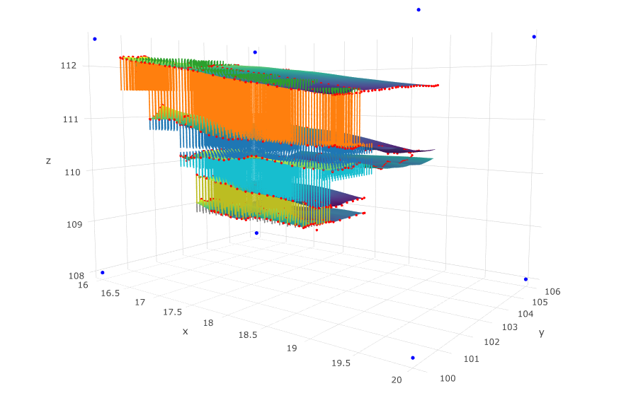

[Screenshot Trench Model 3D](https://nevrome.github.io/IfriElBaroud)

The `data/` directory contains elevation data measured on surfaces and profiles within the trench (`border_* & level_*`) as well as the corner positions of the excavation squares (`corner_excavation_squares`). All coordinates refer to the cave’s internal grid system established for the campaign in 2015. The `code/` directory contains the code for the `attribution_calculation` and a 3D `visualisation` of the results. The latter are stored in `output/`, though only in one possible solution as not all recexcavAAR algorithms are entirely deterministic. The `attribution.csv` table stores the degree of membership for each artificial square to each archaeological horizon and is, therefore, the main result of this analysis.

### How to reproduce:

As the data and code in this repository are complete and self-contained, it can be reproduced with any R environment (> version 3.5.0). The necessary package dependencies are documented in the `deps.yaml` file and can be installed manually or automatically with `automagic::install_deps_file()`. If it’s not possible any more to construct a working environment with these methods due to technological progress, one can use the Docker image.

A Docker image is a lightweight GNU/Linux virtual computer that can be run as a piece of software on Windows, Linux, and OSX. To capture the complete computational environment used for this project we have a Dockerfile that specifies how to make the Docker image that we developed this project in. The Docker image includes all of the software dependencies needed to run the code in this project, including the data and code itself. To launch the Docker image for this project, first, [install Docker](https://docs.docker.com/installation/) on your computer and download the `.tar` file with the ifrielbaroud image [here](https://github.com/nevrome/IfriElBaroud/releases). At the Docker prompt, you can load and run the image with:

```
docker load -i ifrielbaroud_docker_image.tar
docker run -e PASSWORD=ifrielbaroud -dp 8787:8787 --name ifrielbaroud ifrielbaroud
```

This will start a server instance of RStudio. Then open your web browser at localhost:8787 or run `docker-machine ip default` in the shell to find the correct IP address, and log in with rstudio/ifrielbaroud. Once logged in, use the Files pane (bottom right) to navigate to the script files. More information about using RStudio in Docker is available at the [Rocker](https://github.com/rocker-org) [wiki](https://github.com/rocker-org/rocker/wiki/Using-the-RStudio-image) pages.

We developed and tested the package on this Docker container, so this is the only platform that We’re confident it works on. It was built and stored with:

```
docker build -t ifrielbaroud .
docker save -o ifrielbaroud_docker_image.tar ifrielbaroud
```

### Licenses:

Code: MIT http://opensource.org/licenses/MIT year: 2018, copyright holder: Clemens Schmid

Data: CC0 http://creativecommons.org/publicdomain/zero/1.0/ attribution requested in reuse